# Decomposing & Working with Time Series (Time Series #1)

In this post/Jupyter Notebook we’ll look at Time Series and theory surrounding them.

machine-learning

timeseries

workshop

Author

Hampus Londögård

Published

March 11, 2022

# [CA]: Time Series #1 - Decomposing & Working with Time Series

`CA=Competence Afternoon`

This CA is originally found on [kaggle.com/lundet/..](https://www.kaggle.com/lundet/kompetenseftermiddag-crypto-forecasting/), as we entered a competition to predict cryptocurrency prices - G-Research Crypto Forecasting.

**N.B.** This blog/notebook is adapted into a Jupyter notebook that’s easier to replicate, that is we don’t use the Kaggle API + GBs of data that was required for said competition.

1. [Part One - Decomposing & Working with Time Series (theoretical)](https://blog.londogard.com/blog/timeseries-pt-1) ()
2. [Part Two - Predicting Stock Prices (Time Series) using classical Machine Learning](https://blog.londogard.com/blog/timeseries-pt-2) ()
3. [Part Three -Forecasting Cryptocurrency Prices (Time Series) using Deep Learning (PyTorch, Tensorflow/Keras & darts)](https://blog.londogard.com/blog/timeseries-pt-3) ()

Moving on to the content! 🤓

## Time Series Concepts

Time Series has some important attributes that are unique compared to other data types such as `Text`, `Image` and `Tabular`.

Time Series can be decomposed into multiple other time series that together compose the decomposed one (composition baby!).

Trend

Seasonality

Combined

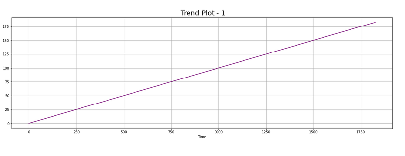

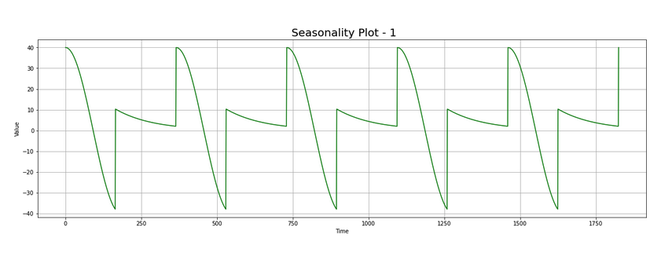

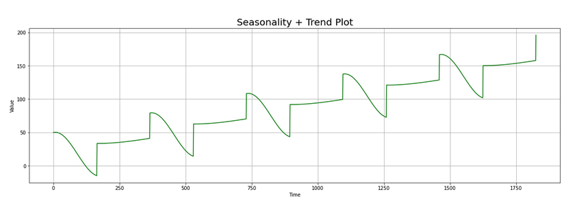

As shown above we can build a time series out of a `Trend` and `Seasonality`, that means we can also decompose the `Combined` into `Trend` and `Seasonality`.

This can be done in a few ways, mostly either through a `additive` or `multiplicative` decomposition.

- **Additive** means that if we **add** `Trend` and `Seasonality` together we create `Combined`.
- **Multiplicative** means that if we **multiply** `Trend` and `Seasonality` together we create `Combined`.

But these two are not enough to compose a full time series, usually we have **noise** too.

Noise

Trend+Seasonality+Noise

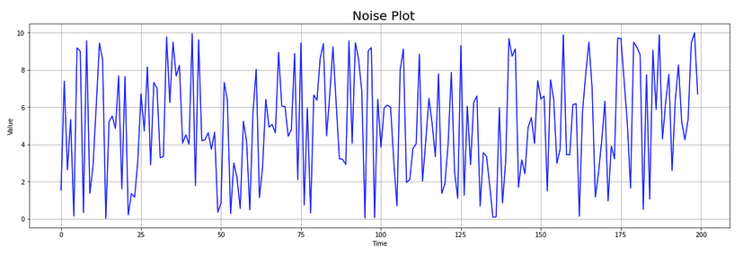

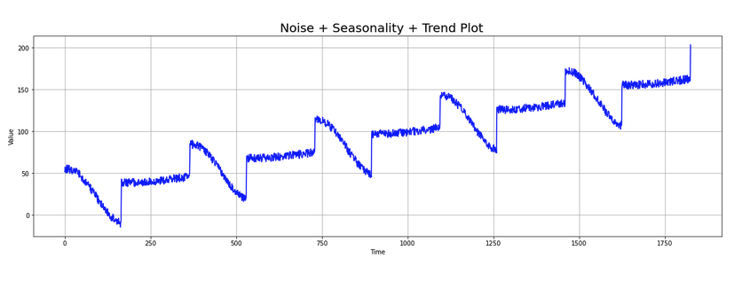

It seems we’re onto something. But still it’s not really how we usually see time series!

What else is left? **Autocorrelation**!

Autocorrelation is a correlation between two observation at different time steps, if values separated by an interval have an strong positive or negative correlation it’s indicated that past values influence the current value.

To keep it simple, if a time series is autocorrelated it’s new state has a correlation with a earlier step.

Autocorrelation

Trend+Autocorrelation

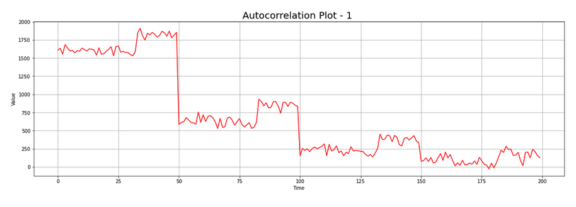

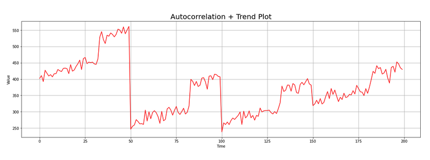

Trend+Seasonality+Autocorrelation

Trend+Seasonality+Autocorrelation+Noise

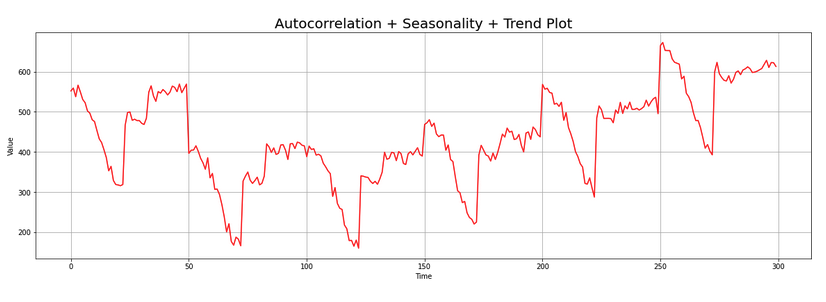

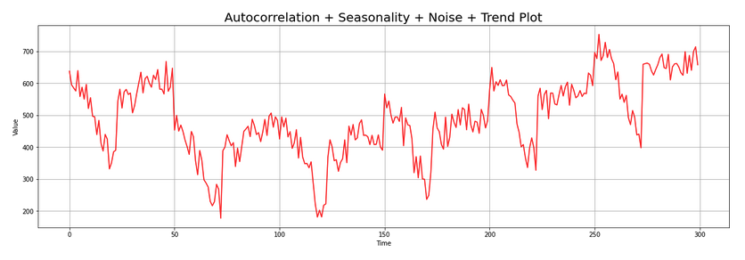

And there we go! 😎

We got a legit timeseries, pat yourself on your back and be proud. We did it.

Let’s get started with *real* data… 🧑‍💻

### Installation & Importing

We need to have libraries which allows us to simplify operations and focus on the essential.

- `pandas` is a `DataFrame` library that allows you to visualize, wrangle, and investigate data in different ways
- `numpy` is a math library which is implemented in `C` and `Fortran` and combined with vectorized code it’s incredibly fast!
  - This is key in Python as Python is a really slow language.
- `pandas_datareader` gives us easy access to different data formats, directly in `pandas`
- `plotly` gives your plots the next level interactivity that you’ve always wanted

```python
from IPython.display import clear_output
!pip install -U pandas_datareader
!pip install plotly

clear_output()
```

And importing our libraries

```python
import pandas as pd # data processing, CSV file I/O (e.g. pd.read_csv)
import numpy as np  # linear algebra
import pandas_datareader as pdr

from datetime import datetime
```

### Reading Cryptocurrency Data

Using `pandas_datareader` we can query multiple API:s, and among them *Yahoo*.  
Yahoo as a financial API that follows stocks, currencies, cryptocurrencies and much more!

Let’s see what we can do.

```python
df = pdr.get_data_yahoo('BTC-USD', start=datetime(2020, 1, 1), end=datetime(2022, 1, 1))
df.head()
```

| Date | High | Low | Open | Close | Volume | Adj Close |
| --- | --- | --- | --- | --- | --- | --- |
| 2020-01-01 | 7254.330566 | 7174.944336 | 7194.892090 | 7200.174316 | 18565664997 | 7200.174316 |
| 2020-01-02 | 7212.155273 | 6935.270020 | 7202.551270 | 6985.470215 | 20802083465 | 6985.470215 |
| 2020-01-03 | 7413.715332 | 6914.996094 | 6984.428711 | 7344.884277 | 28111481032 | 7344.884277 |
| 2020-01-04 | 7427.385742 | 7309.514160 | 7345.375488 | 7410.656738 | 18444271275 | 7410.656738 |
| 2020-01-05 | 7544.497070 | 7400.535645 | 7410.451660 | 7411.317383 | 19725074095 | 7411.317383 |

The data seems great, but one should always validate it visually and programmatically.  
How about plotting it first?

Plotting can be done in multiple ways, let’s start using the `pandas` way. 🐼

> [pandas/docs/plot](https://pandas.pydata.org/docs/reference/api/pandas.DataFrame.plot.html)  
> *Make plots of Series or DataFrame.*  
> Includes options like `x`, `y`, `kind` (e.g. `line`, `bar` or `density`) and much more.

```python
df['Close'].plot()
```

[figure not shown]

Let’s add some interactivity to this, and plot `Low`/`High` on top of that!  
Super simple using `plotly` as the backend! 😎

```python
df[['Close', 'High', 'Low']].plot(backend='plotly')
```

[interactive chart not shown]

**Show plotly chart (as it’s invisible in blog-mode)**

[figure not shown]

You can also plot a candle-stick chart by using

```python
import plotly.graphical_objects as go

fig = go.Figure(data=[go.Candlestick(x=df.index,
                open=df['Open'],
                high=df['High'],
                low=df['Low'],
                close=df['Close'])])
```

The data does look nice, but we need to figure if there’s any issues in the data.  
Graphs might be missing some values that are not clearly visible as there’s so much data. Our final data validation should always be programatical.

## Data Validation

Validating that data makes sense and that there’s no errors is very important when you’re building models. Having outliers, errors and other things can lead to some really weird behaviour.

There’s a few tools we can use:

> [`pd.DataFrame.isna`](https://pandas.pydata.org/docs/reference/api/pandas.DataFrame.isna.html):  
> *Detect missing values. Return a boolean same-sized object indicating if the values are NA. NA values, such as None or numpy.NaN, gets mapped to True values.*  
> 💡The reverse, `notna` also exists.

```python
df.isna().head()
```

| Date | High | Low | Open | Close | Volume | Adj Close |
| --- | --- | --- | --- | --- | --- | --- |
| 2020-01-01 | False | False | False | False | False | False |
| 2020-01-02 | False | False | False | False | False | False |
| 2020-01-03 | False | False | False | False | False | False |
| 2020-01-04 | False | False | False | False | False | False |
| 2020-01-05 | False | False | False | False | False | False |

Can we we make this more *readable*?  
Yes! Using `.any()`, or even ‘cheating’ using `.sum()`

```python
df.isna().any()
```

```
High         False
Low          False
Open         False
Close        False
Volume       False
Adj Close    False
dtype: bool
```

```python
df.isna().any().any() # 👀
```

```
False
```

LGTM ✅

Next up: *Validating that there’s no missing days*

This can be done in multiple ways, but for now I choose to use `.diff`.

> [`pd.DataFrame.diff`](https://pandas.pydata.org/docs/reference/api/pandas.DataFrame.diff.html): *First discrete difference of element.*  
> *Bonus*: Diff can also handle `periods` and `axis` arguments, `period` being how far to diff.

```python
df.index.to_series().diff().dt.days.head()
```

```
Date
2020-01-01    NaN
2020-01-02    1.0
2020-01-03    1.0
2020-01-04    1.0
2020-01-05    1.0
Name: Date, dtype: float64
```

Ok, so we’ve got a series. Try to validate that no `diff` is greater than 1 day using a broadcasted/vectorized operation.

> **hint:** `pandas` automatically broadcast operations by operator overloading, e.g. `>`, `+` etc

I think we can call quits on the validation part for now.

Let’s move on to different ways we can format the data, a common format is `LogReturn`.

## Transforming Data

Because data is very different moving in time we wish to normalize the data somehow. This can be done in multiple ways, some common ways are:

1. `pd.DataFrame.diff` which takes the difference between x_1 and x_2
- The negative aspect of this is that the difference is still not scaled
2. `pd.DataFrame.pct_change` which validates the % difference
3. `LogReturn` which is the logarithmic return between each time step (x_1, x_2, ..).
4. Apply a `Scaler` which scales the data somehow
- Can be `MinMaxScaler` which scales `Min` and `Max` to (0,1) or (-1,1)
- Can be a `MeanScaler` which scales the data to have a mean of 0.

… and more.

We’ll start of with **`LogReturn`** which is common in forecasting of stocks.

```python
def log_return(series, periods=1):
    return np.log(series).diff(periods=periods)
```

```python
df['LogReturn'] = log_return(df['Close'])
df['LogReturn'].head()
```

```
Date
2020-01-01         NaN
2020-01-02   -0.030273
2020-01-03    0.050172
2020-01-04    0.008915
2020-01-05    0.000089
Name: LogReturn, dtype: float64
```

Because `.diff` takes the diff with the next element you’ll end up with a `NaN`, as such we wish to remove the first element.

```python
df = df[1:]
df['Close'].head()
```

```
Date
2020-01-02    6985.470215
2020-01-03    7344.884277
2020-01-04    7410.656738
2020-01-05    7411.317383
2020-01-06    7769.219238
Name: Close, dtype: float64
```

```python
df['LogReturn'].plot()
```

[figure not shown]

Looks nice.

For now we’ll leave it here and move on to looking at `Correlation`.

## Data Analysis: Correlation

```python
df = pdr.get_data_yahoo(['BTC-USD', 'ETH-USD'], start=datetime(2020, 1, 1), end=datetime(2022, 1, 1))
df.head()
```

| Attributes Symbols Date | Adj Close BTC-USD | Adj Close ETH-USD | Close BTC-USD | Close ETH-USD | High BTC-USD | High ETH-USD | Low BTC-USD | Low ETH-USD | Open BTC-USD | Open ETH-USD | Volume BTC-USD | Volume ETH-USD |
| --- | --- | --- | --- | --- | --- | --- | --- | --- | --- | --- | --- | --- |
| 2020-01-01 | 7200.174316 | 130.802002 | 7200.174316 | 130.802002 | 7254.330566 | 132.835358 | 7174.944336 | 129.198288 | 7194.892090 | 129.630661 | 18565664997 | 7935230330 |
| 2020-01-02 | 6985.470215 | 127.410179 | 6985.470215 | 127.410179 | 7212.155273 | 130.820038 | 6935.270020 | 126.954910 | 7202.551270 | 130.820038 | 20802083465 | 8032709256 |
| 2020-01-03 | 7344.884277 | 134.171707 | 7344.884277 | 134.171707 | 7413.715332 | 134.554016 | 6914.996094 | 126.490021 | 6984.428711 | 127.411263 | 28111481032 | 10476845358 |
| 2020-01-04 | 7410.656738 | 135.069366 | 7410.656738 | 135.069366 | 7427.385742 | 136.052719 | 7309.514160 | 133.040558 | 7345.375488 | 134.168518 | 18444271275 | 7430904515 |
| 2020-01-05 | 7411.317383 | 136.276779 | 7411.317383 | 136.276779 | 7544.497070 | 139.410202 | 7400.535645 | 135.045624 | 7410.451660 | 135.072098 | 19725074095 | 7526675353 |

And retrieving only the `Close` to have something to compare.

```python
df = df['Close']
df.head()
```

| Symbols Date | BTC-USD | ETH-USD |
| --- | --- | --- |
| 2020-01-01 | 7200.174316 | 130.802002 |
| 2020-01-02 | 6985.470215 | 127.410179 |
| 2020-01-03 | 7344.884277 | 134.171707 |
| 2020-01-04 | 7410.656738 | 135.069366 |
| 2020-01-05 | 7411.317383 | 136.276779 |

Let’s validate the correlation, e.g. how our values correlate to each other!

```python
df.corr().style.background_gradient(cmap="Blues")
```

| Symbols | BTC-USD | ETH-USD |
| --- | --- | --- |
| BTC-USD | 1.000000 | 0.903202 |
| ETH-USD | 0.903202 | 1.000000 |

The correlation looks pretty high… We can use `seaborn` to show even better data by adding the plots.

```python
import seaborn as sns

sns.pairplot(df)
```

[figure not shown]

Indeed, looks very correlated! 🤩

What conclusions can we take from the above chart? Cryptocurrencies using daily data **are indeed correlated**, that is ETH prices depends on BTC and v.v.

This blog is getting close to its end, and as such we won’t go further in depth of this.  
For the reader an excercise would be to predict the BTC price depending on ETH, which should be possible based on this correlation. We’ll go further into this later.

## Data Analysis: Decomposition

Decomposing Time Series means that we try to find seasonality, trends and other things. This can be done using `statsmodels` which is a very impressive library that originally was done in `R` but now exists in Python.

```python
from statsmodels.tsa.seasonal import seasonal_decompose

res = seasonal_decompose(df['BTC-USD'])
res.plot()
```

[figure not shown]

Looks nice and dandy! But we can modify this further by adding `model` and `freq` parameter to validate how it looks by decomposing either through `model=multiplicative` or `additive`, and updating the `freq` (`period` in the newest version) to decompose it based on different periods.

```python
res = seasonal_decompose(df['BTC-USD'], model='additive', period=365) # Try weekly or monthly decomposition.
res.plot()
```

[figure not shown]

We’re now looking at our final data analysis step, *Fast Fourier Transform*, A.K.A. FFT!

## Data Analysis: FFT

We’ll also add an Fast Fourier Transform which can show which frequencies the data “resets” at.

```python
import numpy as np
import matplotlib.pyplot as plt

fft = np.fft.rfft(df['BTC-USD'])

plt.step(range(len(fft)), abs(fft))

plt.xscale('log')
plt.xlim([0.1, max(plt.xlim())])
plt.xticks([1, 365.2524], labels=['1/Year', '1/day'])
_ = plt.xlabel('Frequency (log scale)')
```

[figure not shown]

That’s it for this time. Make sure to view **part 2** if you want to start predicting some data, and in **part 3** we’ll do the final prediction where we’ll look at different forecast horizons!

To learn more about Time Series and how one can analyze them please view the other parts,

1. [Part One - Decomposing & Working with Time Series (theoretical)](https://blog.londogard.com/blog/timeseries-pt-1)
2. [Part Two - Predicting Stock Prices (Time Series) using classical Machine Learning](https://blog.londogard.com/blog/timeseries-pt-2)
3. [Part Three -Forecasting Cryptocurrency Prices (Time Series) using Deep Learning (PyTorch, Tensorflow/Keras & darts)](https://blog.londogard.com/blog/timeseries-pt-3)